# Modelos tentativos

Miguel G.

Otoño 2022

# Identificación de modelos tentativos para ajustar un modelo ARMA(p,q)

Recuerda que para ajustar un modelo tentativo debemos observar la autocorrelación (ACF) y la autocorrelación parcial de los valores de $y_t$ con su variable rezagada varios periodos, recuerda que nos interesan aquellas correlaciones que sean estadísticamente significativas, es decir, aquellas que son diferentes de cero.

Si las autocorrelaciones de la muestra se desvanecen exponencialmente hacia cero y las autocorrelaciones parciales de la muestra se cortan de forma abrupta, el modelo requerirá términos autorregresivos. Es decir un modelo $AR(p)$.

Si las autocorrelaciones de la muestra se cortan manera abrupta y las autocorrelaciones parciales de la muestra se desvanecen, el modelo requerirá términos de promedio móvil. Es decir un modelo $MA(q)$.

Si tanto las autocorrelaciones de la muestra como las autocorrelaciones parciales de la muestra se desvanecen, tanto los términos autorregresivos como los términos de promedio móvil están indicados. Un modelo $ARMA(p,q)$

Los patrones de autocorrelación y autocorrelación parcial de los procesos de promedio móvil autorregresivos se resumen como sigue:

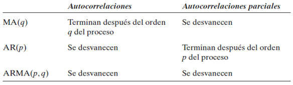

Figura 1: Patrones de la ACF y PACF

Para poner en práctica esta identificación tentativa consideremos los siguientes escenarios. A continuación se muestran series simuladas con cierto modelo y se observa su ACF y PACF para observar como se comporta la autocorrelación, posteriormente se presentar algunas series a las cuales debes proponer un modelo tentativo según su ACF y PACF.

# Ejemplo 1: AR(1)

Considera de ejemplo la serie $X_1$ la cual fue generada por un proceso $AR(1)$ con la siguiente ecuación:

$$y_t = - 0.8y_{t-1}+\epsilon_t$$

¿Cómo se que es un modelo AR(1)? Para ello observo su ACF y PACF

Su ACF va desvaneciéndose, oscilando de correlación negativa a positiva, mientras que la PACF se corta de manera abrupta **después del primer rezago**

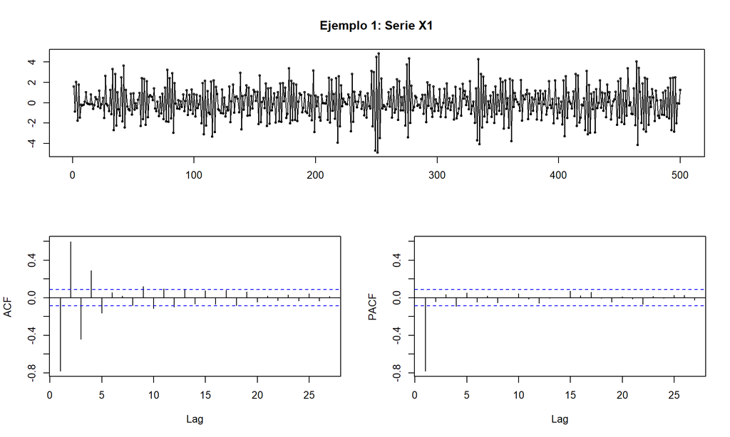

Nota que pasa si cambiamos el signo del coeficiente asociado al primer rezago, es decir, su ecuación es:

$$y_t = 0.8y_{t-1}+\epsilon_t$$

¿Cómo se que es un modelo AR(1)? Para ello observo su ACF y PACF

Su ACF va desvaneciéndose, de forma exponencial, mientras que la PACF se corta de manera abrupta **después del primer rezago**

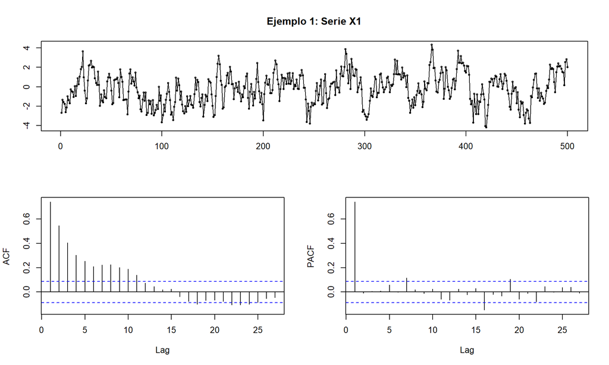

# Ejemplo 2: AR(2)

Considera de ejemplo la serie $X_2$ la cual fue generada por un proceso $AR(2)$ con la siguiente ecuación:

$$y_t = 0.3y_{t-1} + 0.29y_{t-2} + \epsilon_t$$
¿Cómo se que es un modelo AR(2)? Para ello observo su ACF y PACF

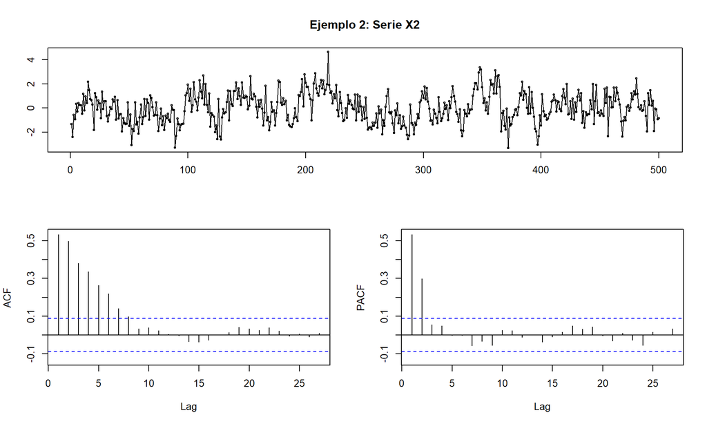

Nota que pasa si cambiamos el signo del coeficiente asociado al primer rezago a negativo y el del segundo rezago a positivo, es decir, su ecuación es:

$$y_t = - 0.3y_{t-1} + 0.29y_{t-2} + \epsilon_t$$

¿Cómo se que es un modelo AR(2)? Para ello observo su ACF y PACF

Su ACF va desvaneciéndose, oscilando de correlación negativa a positiva, mientras que la PACF se corta de manera abrupta **después del segundo rezago**

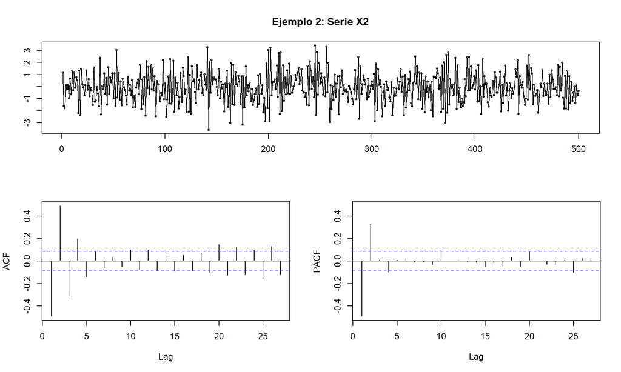

**Para procesos $AR(p)$ puros el patrón será el mismo, la gráfica de la ACF se ira desvaneciendo mientras que la PACF se cortará de manera abrupta después del rezago $p$.**

# Ejemplo 3: MA(1)

¿Cómo se que es un modelo MA(1)? Para ello observo su ACF y PACF

Su ACF se corta de manera abrupta **después del primer rezago**, mientras que la PACF va desvaneciéndose, oscilando de correlación negativa a positiva

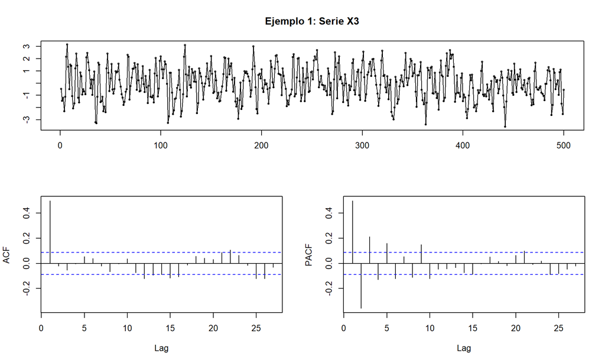

¿Cómo se que es un modelo MA(1)? Para ello observo su ACF y PACF

Su ACF se corta de manera abrupta **después del primer rezago**, mientras que la PACF va desvaneciéndose de manera exponencial

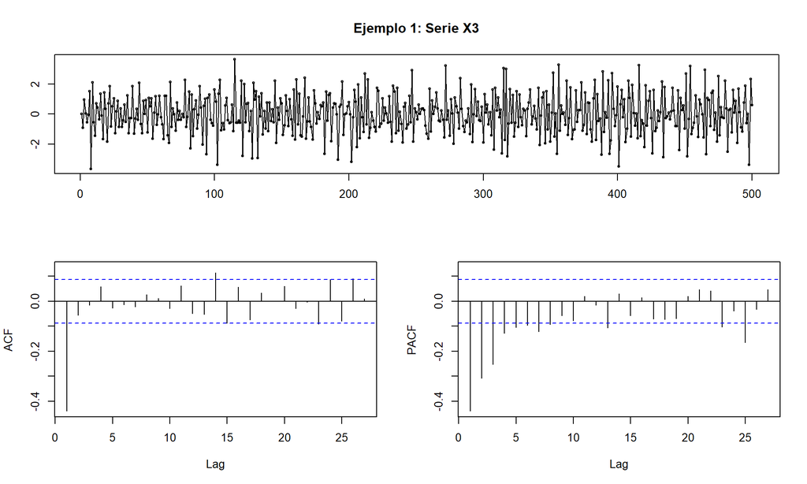

# Ejemplo 4: MA(2)

Considera de ejemplo la serie $X_4$ la cual fue generada por un proceso $MA(2)$ con la siguiente ecuación:

$$y_t = 0.4\epsilon_{t-1}+0.39\epsilon_{t-2}+\epsilon_t$$

Su ACF se corta de manera abrupta **después del segundo rezago**, mientras que la PACF va desvaneciéndose, oscilando de correlación negativa a positiva

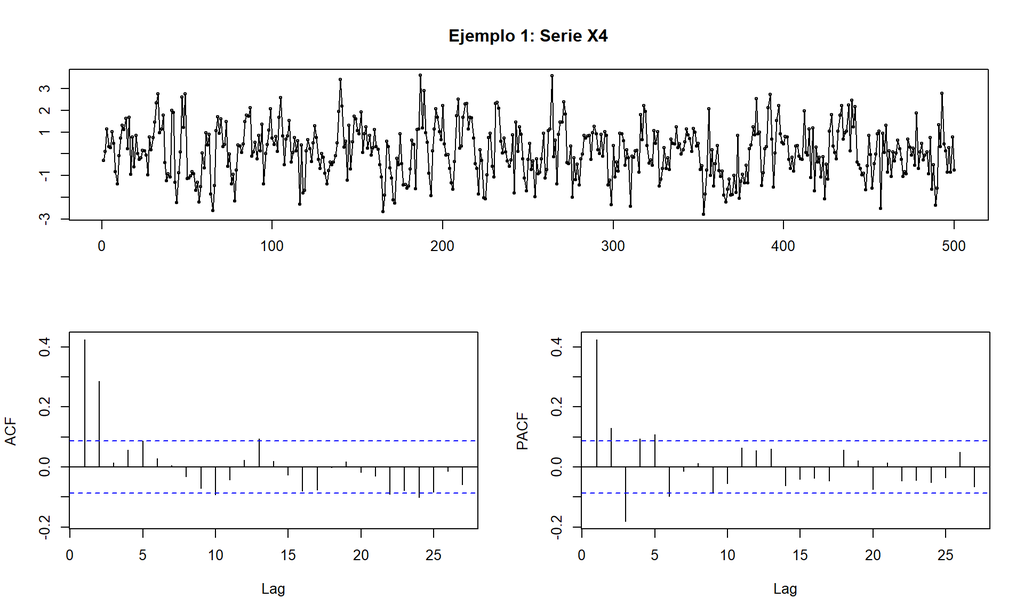

Nota que pasa si cambiamos el signo del coeficiente asociado al primer rezago del error, es decir, su ecuación es:

$$y_t = -0.4\epsilon_{t-1}+0.39\epsilon_{t-2}+\epsilon_t$$

¿Cómo se que es un modelo MA(2)? Para ello observo su ACF y PACF

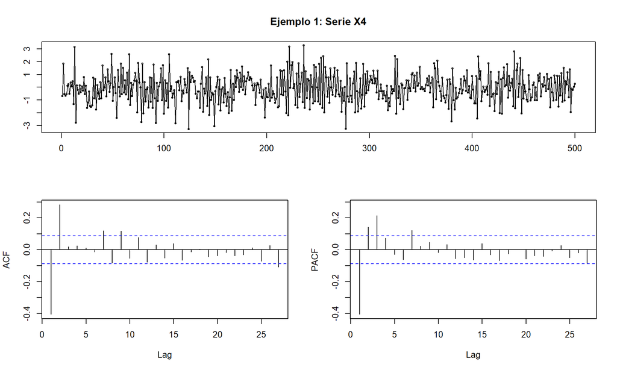

**Para procesos $MA(q)$ puros el patrón será el mismo, la gráfica de la ACF se cortará de manera abrupta después del rezago $q$, mientras que la PACF se ira desvaneciendo**

# Ejemplo 5: ARMA(p,q)

Los modelos ARMA, es decir, aquellos que tienen tanto un componente autorregresivo como de media móvil, son un poco menos intuitivos de identificar, incluso puede darse alguna situación de ambigüedad, es por ello que el modelo que propongamos es tentativo, es decir, para validarlo necesitamos estimarlo, analizar la significancia de los coeficientes estimados, analizar los residuales y los criterios de información, aunque para un ojo experto puede bastar mirar la ACF y PACF, mientras adquirimos experiencia utilizaremos este enfoque.

A continuación se muestran algunos modelos $ARMA(p,q)$ simulados y sus correlogramas.

## ARMA (1,1)

La siguiente serie es un modelo $ARMA(1,1)$, observemos como se comporta su ACF y PACF, nota que despues del primer rezago tanto la ACF como la PACF se corta rápidamente después del primer rezago

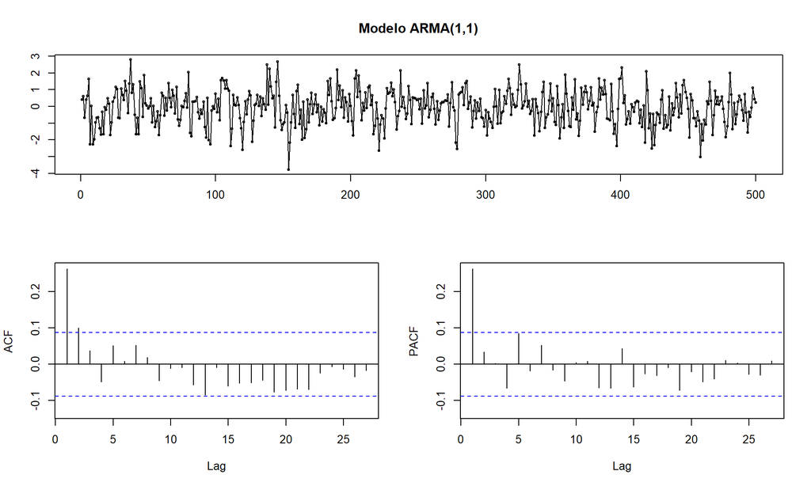

## ARMA (2,1)

De antemano sabemos que es un modelo ARMA(2,1) en vez de un ARMA(2,2), pero esto en realidad no lo sabríamos, hasta que estimemos el modelo y veamos su ajuste no podremos saber si el modelo tentativo ARMA(2,2) es bueno o no.

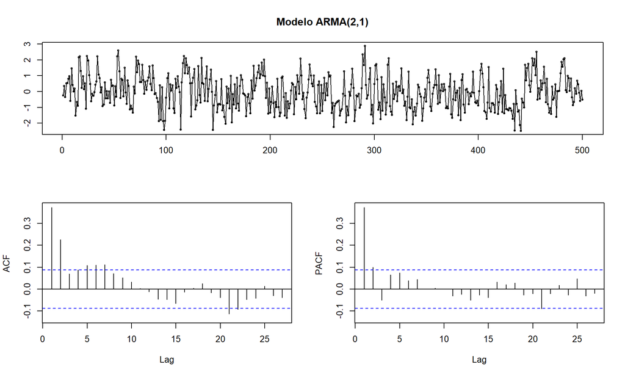

## ARMA(1,2)

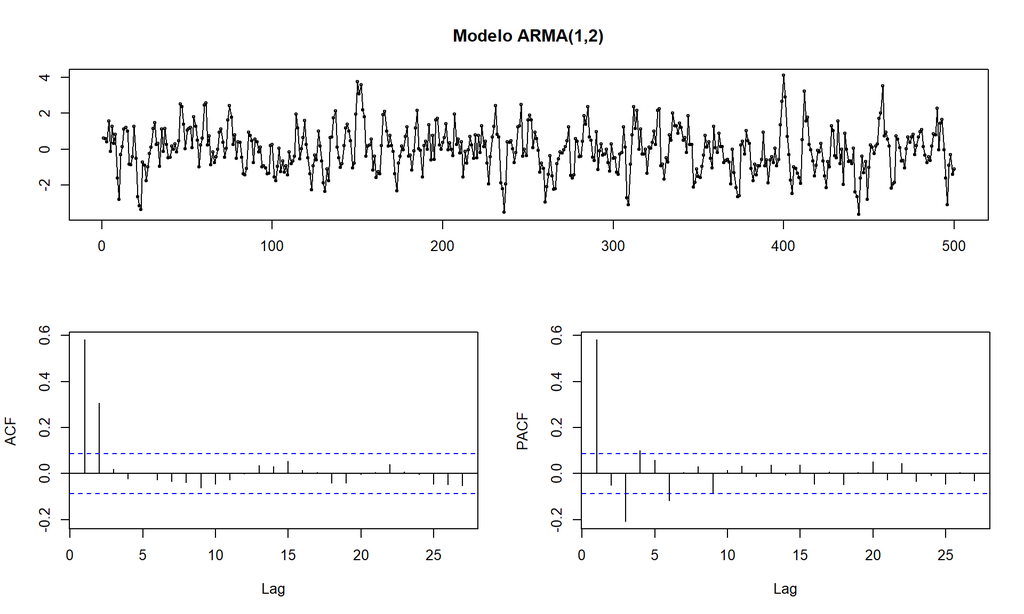

## ARMA(3,2)

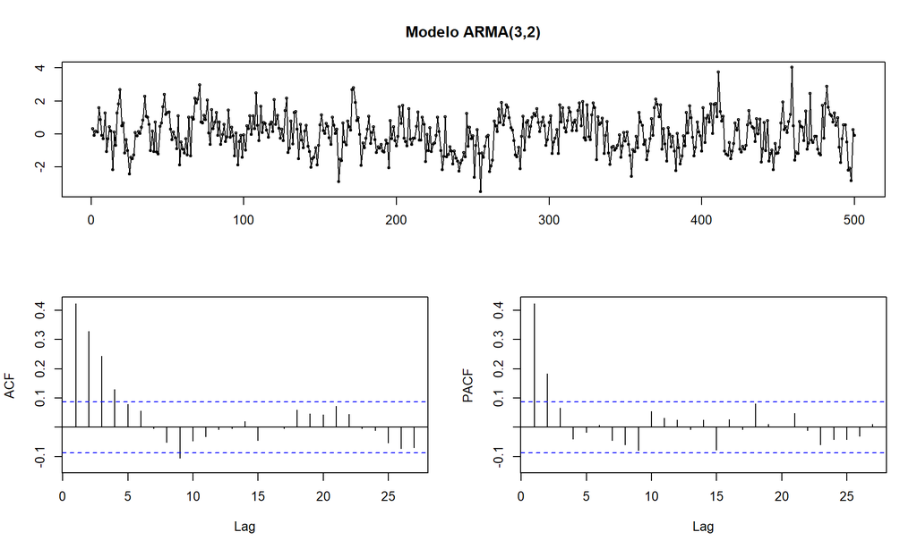

## ARMA(1,3)

Sucede algo similar que el caso anterior, de antemano sabemos que es un modelo ARMA(1,3) pero esto en realidad no lo sabríamos, hasta que estimemos el modelo y veamos su ajuste no podremos saber si el modelo tentativo ARMA(1,2) es bueno o no.

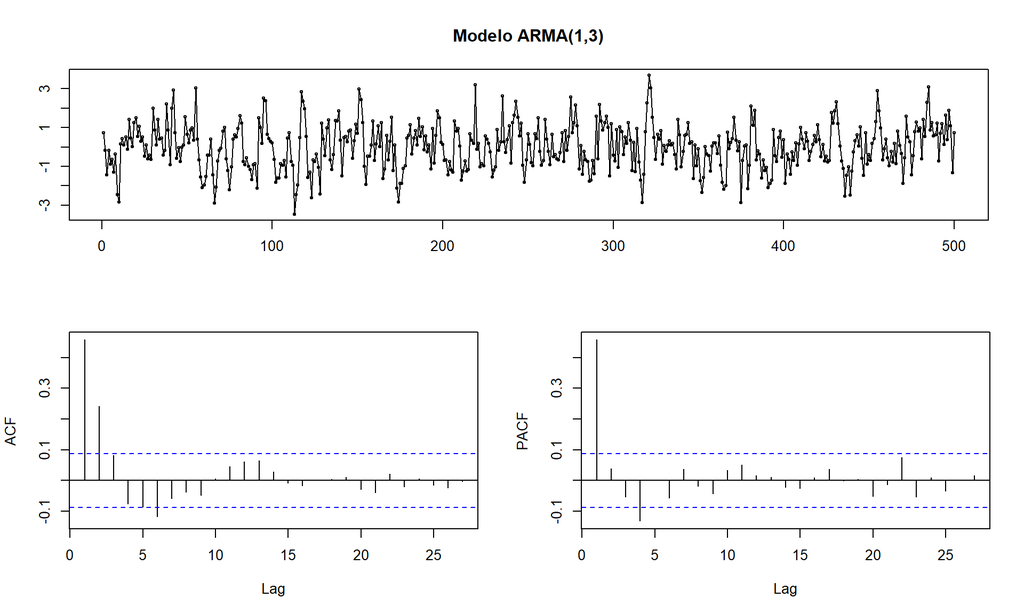